# Grundlagen der Resilienz

Cyber Security Management · Termin 1

Prof. Dr. Dirk Loomans

Hochschule Mainz · dirk.loomans@hs-mainz.de

## About …

**Prof. Dr. Dirk Loomans**, Diplom-Physiker

- Studium Physik mit Informatik, Universität Bayreuth; Promotion in theoretischer Polymerphysik, Universität Freiburg i. Br.
- ehem. Partner Cyber Security and Resilience bei KPMG
- Hochschule Mainz, Fachbereich Wirtschaft: Wirtschaftsinformatik, insbesondere Cyber Security und Softwareentwicklung (WiSe 2011/12 – SoSe 2015 und seit SoSe 2025)
- Lehre: Projektmanagement, Cyber-Resilienz, IT-Security, Digital Business
- Forschung: KI und Cyber, Digitale Souveränität
- Fun Fact: Hobbybrauer und Fastnachts-Aficionado

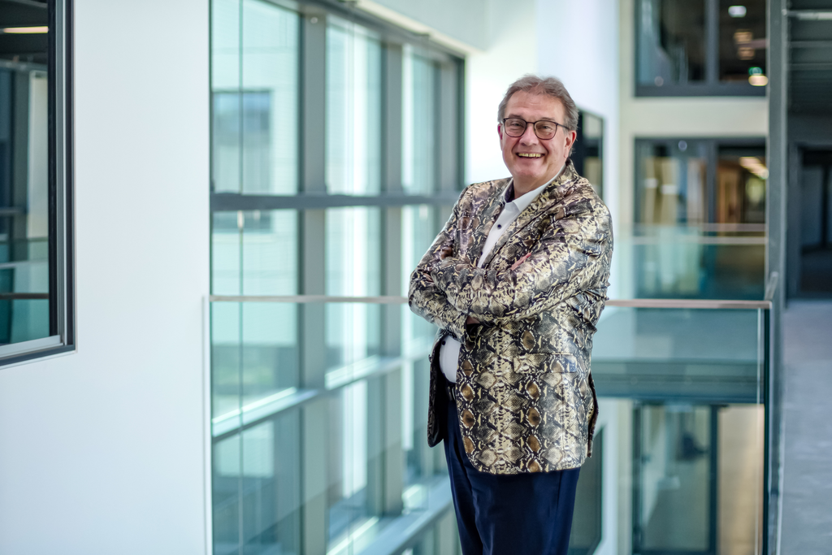

## Zugang zum Kurs in OLAT

Kursunterlagen, Skripte und Ankündigungen liegen in OLAT.

Zugangskennwort: CSMWS26ECR

## Semesterüberblick

1. **Grundlagen der Resilienz: Safety & Security** ← heute
2. Modelle und Messbarkeit
3. Resilienz-Architekturen
4. Cyber-Bedrohungen und Resilienzstrategien
5. Resilienz als Organisationsfähigkeit
6. Rollen und Verantwortlichkeiten
7. Technische Resilienz I: Backup, DR, Notfalltests
8. Technische Resilienz II: Zero Trust, Microsegmentation, Cloud, Netz
9. Sonderthemen OT und KI · 10. Resilienz der Zukunft · 11. Klausur

## Agenda

- Einleitung & Lernziele
- Grundlagen der Resilienz
- Safety vs. Security
- Technische Resilienzprinzipien
- Physikalisch-systemische Perspektive
- Praktische Beispiele & Fallstudien
- Übung und Reflexionsfragen
- Zusammenfassung & Ausblick

## Warum Resilienz wichtig ist

IT-Systeme sind nie vollkommen sicher.

Angriffe, Ausfälle und Fehlbedienungen sind unvermeidlich.

**Entscheidend ist: Wie schnell können wir uns erholen und weiterarbeiten?**

Diskussionsfrage: Wie lange darf euer Lieblingsspiel down sein?

## Was bedeutet Resilienz?

- Resilienz = Widerstands- und Anpassungsfähigkeit bei Störungen.
- Herkunft: Physik, Psychologie, Systemtheorie – heute technische und organisatorische Systeme.
- In der IT: Systeme bleiben trotz Störungen funktionsfähig oder erholen sich schnell.

[figure not shown]

## Safety vs. Security – der Unterschied

**Safety:** Schutz vor unbeabsichtigten Fehlern und Unfällen – Hardwaredefekt, Stromausfall, Brand.

**Security:** Schutz vor absichtlichen Angriffen – Ransomware, Social Engineering, Hacking.

Beide beeinflussen die Resilienz eines Systems.

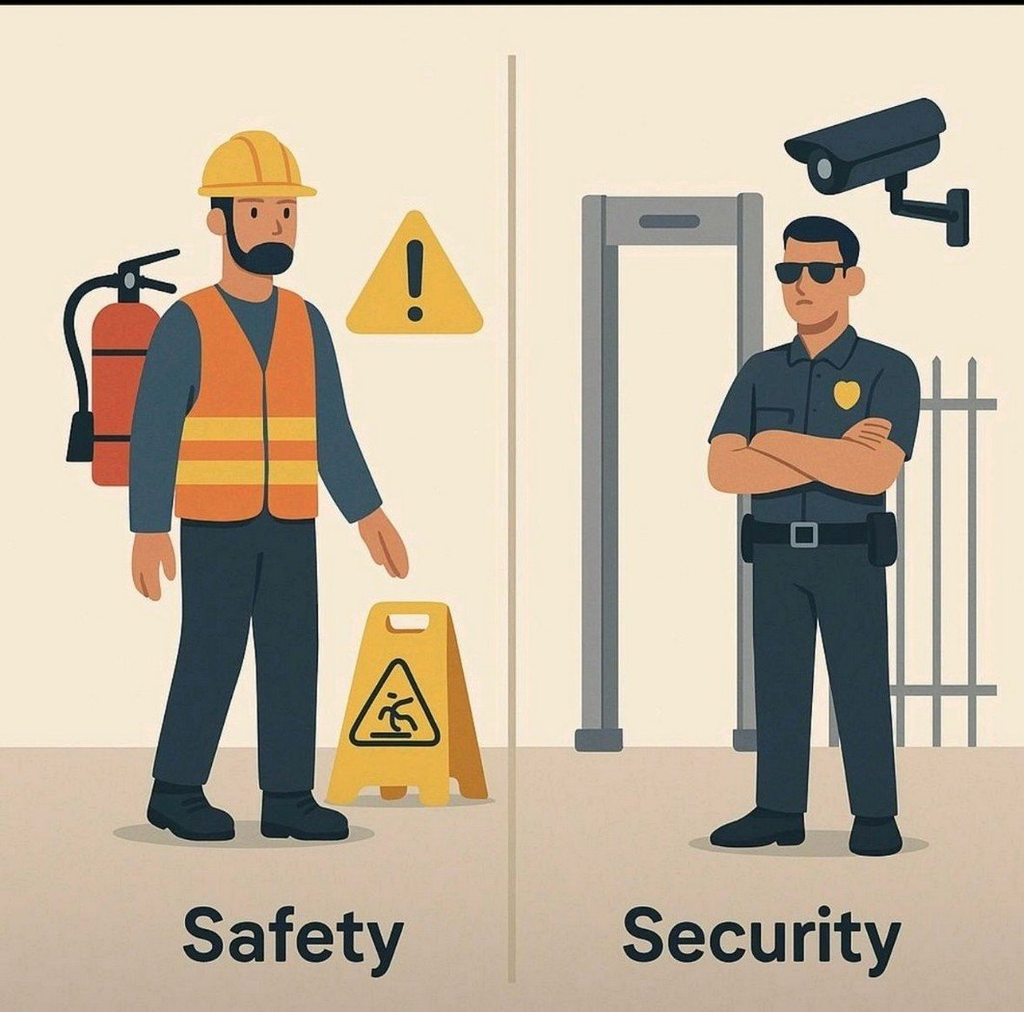

## Resilienz verbindet beides

Ziel: nicht Unverwundbarkeit, sondern Reaktions- und Wiederherstellungsfähigkeit.

**Safety + Security + Adaptivität = Resilienz**

Fokus: robust designen, Störungen erkennen, reagieren, wiederherstellen.

[figure not shown]

## Physikalische Perspektive (Analogie)

- Pendel / Schwingkreis: Störung → Auslenkung → Rückkehr zur Balance.
- Elastizität vs. Fragilität: Gummi vs. Glas.
- Übertragung auf IT-Systeme und Organisationen: Monitoring, Alerting und Autoscaling wirken wie Regelkreise.

[figure not shown]

## Technische Resilienzprinzipien

- **Redundanz** – mehrere Wege und Komponenten
- **Diversität** – heterogene Komponenten reduzieren Kaskadenfehler
- **Wiederherstellbarkeit** – Backups, DR-Prozesse, Automatisierung
- **Adaptivität** – Skalierung, Umschalten, Lernen

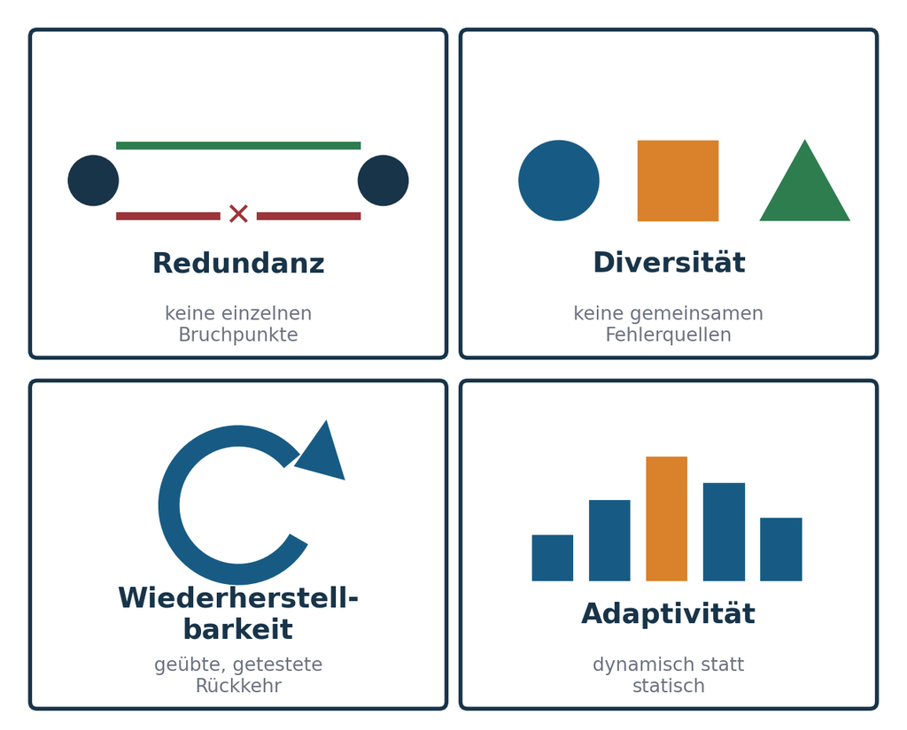

## Safety & Security in Cyber-Systemen

- Beispiele: Smart Home, autonome Fahrzeuge, Cloud-Gaming
- Risikoanalyse: Wo kippt Safety in Security und umgekehrt?
- Priorisierung kritischer Funktionen

## Warum Prävention nicht reicht

- Zero-Days, Lieferketten, menschliche Fehler
- 100 % Prävention gibt es nicht.
- **Resilienz ist die letzte Verteidigungslinie.**

„Sicherheit schützt – Resilienz überlebt.“

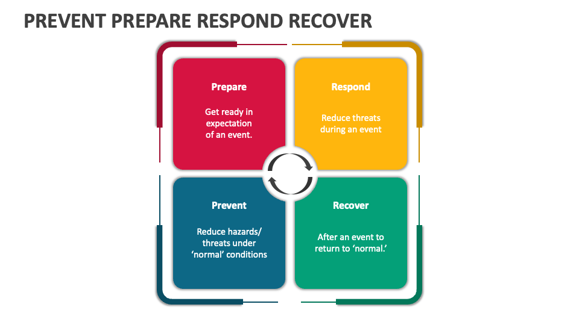

## Relevanz für Cyber Security Management

- Resilienz ist ein Management- und Architekturthema.
- Einbettung in Standards und Frameworks: NIST, ISO/IEC 27031, BSI 200-4, ENISA.
- Verbindung zu Incident Response, BCM und IT Service Continuity Management.

## Praxisbeispiele (Diskussion)

**Ransomware in der Verwaltung** – Recovery und Kommunikation sind entscheidend: offline verifizierte Backups, priorisierter Wiederanlauf nach BCM-Plan.

**DDoS auf einen Online-Service** – Skalierung und Traffic-Filterung: CDN, WAF, elastische Kapazität, transparente Statuskommunikation.

**Frage:** Welche Maßnahmen beschleunigen die Wiederherstellung?

## Übung: Safety oder Security?

Gruppenaufgabe mit Szenarien: Cloud-Gaming, Krankenhaus-IT, Smart Home, Auto, Banking-App.

1. Risiken identifizieren
2. Safety vs. Security zuordnen
3. Resilienzmaßnahmen vorschlagen

5-Minuten-Kurzpräsentation pro Gruppe.

## Ausblick & Hausaufgabe

**Zusammenfassung:** Safety ≠ Security – Resilienz integriert beides.

**Nächste Sitzung:** Modelle und Messbarkeit der Resilienz.

**Hausaufgabe:** Ein Beispiel recherchieren, das sich nach einer Störung besonders schnell erholte.

Kapitel zum Termin · Glossar · Quellen